# Lab 4 sampling distribution

Di Deng

2020/7/5

## Sampling distribution

**Sampling distribution is the distribution of a statistic computed from a random sample with a given sample size n, drawn from a population.** This statistic of interest can be **anything** obtained from that sample, such as sample mean, median, the first quartile, range, max, min and etc. The reason why we care about the distribution of a sample statistic is that it allows us to learn more about the underlying distribution of the population, a.k.a. statistical inference.

If you are confused by this concept, try to think of it as nested samples—**samples of samples**. Intuitively, if one is curious about the individuals of a population, he/she wants to learn about them by drawing a sample from the population. In the case of sampling distribution, we are interested in a statistic derived from a single sample, or in other words, how the each individual samples behave. So what we want is a sample of samples, thus sampling distribution.

### Example

You will learn about **Central Limit Theorem (CLT)** in this class, which tells us about the asymtotical distribution of sample means for any population distribution. That is when the sample size n is approaching infinite, the sample mean is following a normal distribution, regardless of the underlying population distribution.

### Standard error

Standard error is simply the **standard deviation of the sampling distribution**, just to distinguish it from the standard deviation of population that we normally use.

## Setting random seed

To generate random variables, computer science resorts to a “black box” mathematical formula or algorithm. The sequence of all following numbers are completely determined by the inital “seed”. However, don’t you worry about this pseudorandomness, since the numbers generated by this algorithm are following the designed distribution and statistically independent. Therefore, once you set a seed before all your random generators, the same results will show up every time you run the same codes, which is a big advantage for **the purpose of reproducibility**.

## Packages used

### Dplyr

*Dplyr* is a powerful package when it comes to data manipulation. Common functions are select, mutate, transmute filter, group_by, arrange, count, summarise, slice, sample_n, etc. Use ? followed by function names in R console to look at the documents i.e. ?select, or refer to the data wrangling cheatsheet: https://rstudio.com/wp-content/uploads/2015/02/data-wrangling-cheatsheet.pdf

#### Pipeline operator %>%

##### Examples

Here we load package *tidyverse*. It is the parental package of common packages such as *dplyr*, *ggplot2*, *tidyr*, *purrr*, etc.

```r
library(tidyverse)
```

Let’s say we want to select a continuous variable from a particular dataset, group these varaibles by two categorical variables, and obtain the first three observations with the largest values within each subcategory. What would you do?

```r
mpg %>% select(cty, manufacturer, class) %>%
  group_by(manufacturer, class) %>%
  arrange(desc(cty), .by_group = T) %>%
  slice(1:3) %>%
  head(9)
```

```
## # A tibble: 9 x 3
## # Groups:   manufacturer, class [3]
##     cty manufacturer class
##   <int> <chr>        <chr>
## 1    21 audi         compact
## 2    21 audi         compact
## 3    20 audi         compact
## 4    17 audi         midsize
## 5    16 audi         midsize
## 6    15 audi         midsize
## 7    16 chevrolet    2seater
## 8    16 chevrolet    2seater
## 9    15 chevrolet    2seater
```

What would this be without *%>%*?

```r
head(slice(arrange(group_by(select(mpg, cty, manufacturer, class), manufacturer, class), desc(cty), .by_group = T), 1:3), 9)
```

```
## # A tibble: 9 x 3
## # Groups:   manufacturer, class [3]
##     cty manufacturer class
##   <int> <chr>        <chr>
## 1    21 audi         compact
## 2    21 audi         compact
## 3    20 audi         compact
## 4    17 audi         midsize
## 5    16 audi         midsize
## 6    15 audi         midsize
## 7    16 chevrolet    2seater
## 8    16 chevrolet    2seater
## 9    15 chevrolet    2seater
```

Which coding style do you prefer?

### Infer

We use *rep_sample_n* in *infer* package to repeatedly draw samples with certain sample size from a dataset.

```r
library(infer)
```

#### Example

Here, the dataset has number of COVID 19 cases for each county. First we extract all statistics for July 4th.

```r
covid19_usa_county = read.csv("../Data/covid19_county.csv")
covid19_usa_county_704 = covid19_usa_county %>% filter(date == "2020/7/4")
```

Then we want to know the sampling distribution of sample mean, which is just the distribution of average cases per county. Here, we use *rep_sample_n* function to draw 5000 samples from the 3086 counties and each sample has 1000 counties. Notice that we set a seed here, because *rep_sample_n* involves generating random numbers and we want to produce the same results.

```r
set.seed(709)
sampling_data = rep_sample_n(covid19_usa_county_704, size = 1000, replace = T, reps = 5000)
sampling_data %>% head(10)
```

```
## # A tibble: 10 x 7
## # Groups:   replicate [1]
##    replicate date     county        state          fips  cases deaths
##        <int> <fct>    <fct>         <fct>         <int>  <int>  <int>
##  1         1 2020/7/4 Grenada       Mississippi   28043    479      5
##  2         1 2020/7/4 Midland       Texas         48329    772     15
##  3         1 2020/7/4 Union         Illinois      17181    194     19
##  4         1 2020/7/4 Grafton       New Hampshire 33009     87      1
##  5         1 2020/7/4 Maverick      Texas         48323    519      5
##  6         1 2020/7/4 Ripley        Indiana       18137    115      7
##  7         1 2020/7/4 New York City New York         NA 221395  22630
##  8         1 2020/7/4 Franklin      Massachusetts 25011    373     55
##  9         1 2020/7/4 Allen         Louisiana     22003    321     11
## 10         1 2020/7/4 Ozark         Missouri      29153      2      0
```

```r
sample_of_means = sampling_data %>% group_by(replicate) %>%
  summarise(avg_cases = mean(cases))
sample_of_means %>% head(10)
```

```
## # A tibble: 10 x 2
##    replicate avg_cases
##        <int>     <dbl>
##  1         1     1077.
##  2         2      583.
##  3         3     1260.
##  4         4      822.
##  5         5      836.
##  6         6      718.
##  7         7     1050.
##  8         8      768.
##  9         9      993.
## 10        10      820.
```

Then we plot a histogram for the average cases per county. It has a bell shape of a normal distribution, but with a slight right skewness. Note that had the population and our sample size been much larger, this histogram should have looked very similar to a normal curve.

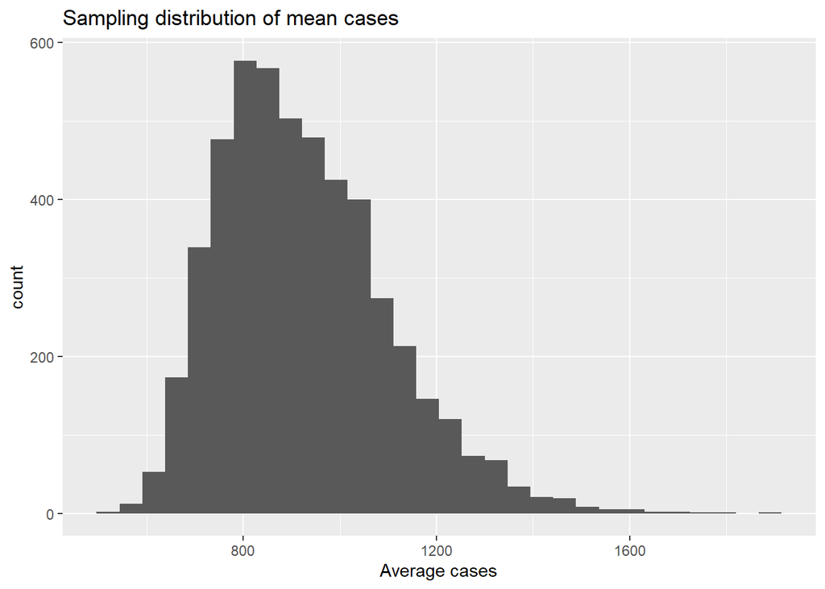

```r
ggplot(sample_of_means) + geom_histogram(aes(x = avg_cases)) + ggtitle("Sampling distribution of mean cases") + xlab("Average cases")
```

## Exercises

### 1 (10%)

Normal distribution is the most commonly used distribution in data science. Here make sure that via this exercise, you are familiar with univariate normal distribution in R.

- dnorm: gives you the density of a normal distribution—the value of the normal curve at some point.
- pnorm: gives you the probability of a normal distribution—probability of greater or smaller than a chosen point.
- qnorm: inverse of pnorm—gives you the value of a point for which the probability of greater or smaller is a chosen value.
- rnorm: gives you random variables from a normal distribution.

Refer to https://www.statology.org/dnorm-pnorm-rnorm-qnorm-in-r/ for more information.

What is the probablity of greater than 5 for $N(3, 2)$ (3%)

What is the 56 percentile for $N(9,3)$ (3%)

Generate 500 random samples from $N(3,1)$ and make a histogram (4%)

### 2 (10%)

Another important distribution is binomial. It has two parameters: number of trials and probability of success.Similarly, dbinom, pbinom, qbinom, rbinom are the functions for binomial distribution, with the same purposes as the ones of normal distribution above.

Refer to https://www.statology.org/dbinom-pbinom-qbinom-rbinom-in-r/ for more information.

What is the probablity of greater than 5 for $Bin(10, 0.4)$ (3%)

What is the 56 percentile for $Bin(10,0.3)$ (3%)

Generate 500 random samples from $Bin(8,0.7)$ and make a histogram (4%)

### 3 (15%)

Obtain the counties with the highest death cases within each state, on 2020/07/03. Only show the top 10 counties in terms of deaths.

### 4 (15%)

Obtain the death rates for each state on 2020/07/02. Show the top ten states in terms of death rate.

### 5 (10%)

Plot a histogram of county-wise death rates, on 2020/07/01

### 6 (20%)

Obtain the sampling distribution of mean of county-wise death rates, on 2020/06/30, with sample size 50 and 5000 samples.

### 7 (20%)

Use a larger sample size, such as 100, or 500. Do the same task. Describe the change in the sampling distribution. What is the theorem behind this? (15%)

What would happen if we increase number of samples drawn from 5000 to 10k? (5%)

Data for this lab was sourced from https://www.kaggle.com/sudalairajkumar/covid19-in-usa

This lab was written by Daniel Deng, with Pro. Kelly Moran’s lab 4 as reference.